# Análisis evolución Covid-19 Chile casos y decesos (16/04/2020)

Claudio Bustos

16/4/2020

- Reportes anteriores: https://github.com/clbustos/analisis_covid19_chile

## Análisis de series de casos

La serie de casos se hace hace partir de los 25 casos, excepto para Atacama y Aysén - donde no hay casos nuevos en los últimos días, para facilitar la comparación desde un punto de un punto de partida común. En la serie total se observa un estancamiento de la tasa en la última semana. Ya se ve con claridad que el aumento de tasa de la región Metropolitana de la última semana es estable: ¿será que los casos se han traslado a otras comunes?. En Maule también la tasa permanece constante, pero pareciera ser que se produce por brotes en comunas que antes no tenían casos.

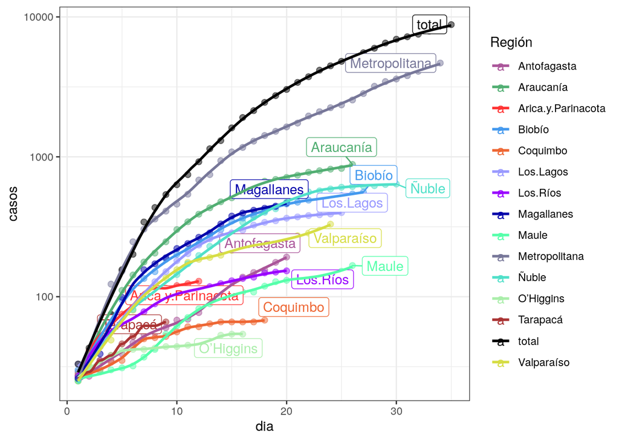

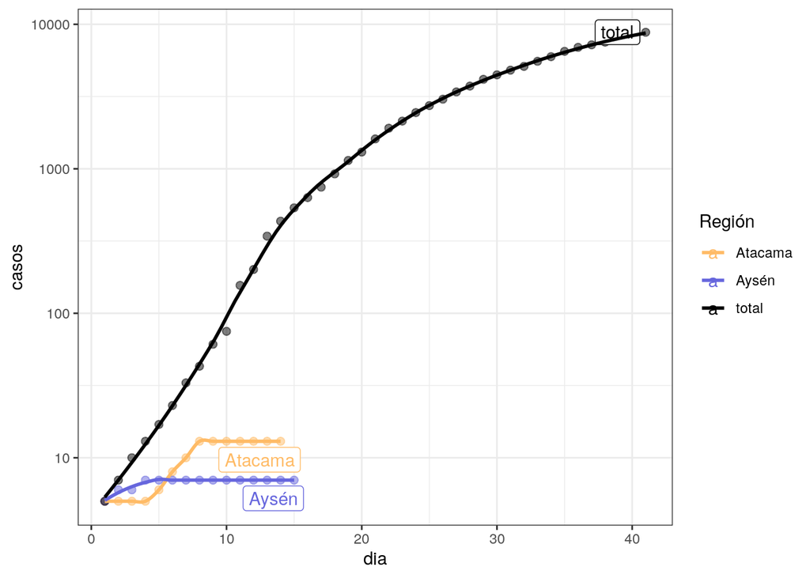

La serie por región se hace partir de los 5 primeros casos.

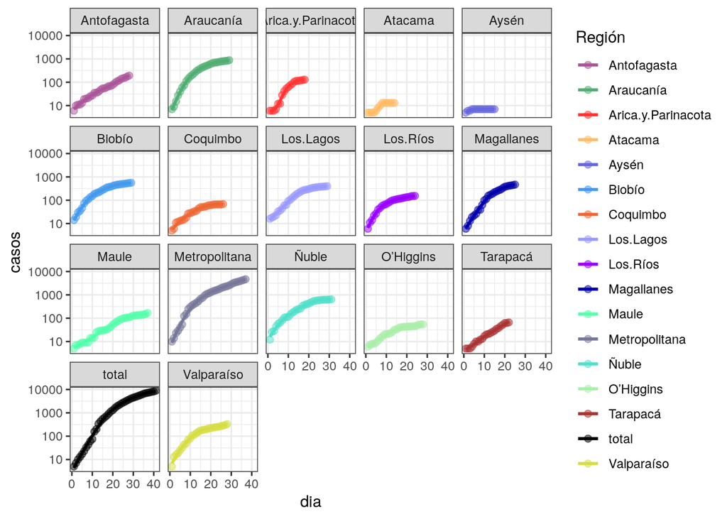

Con respecto a la cantidad de casos por día, podemos ver tasas estables del 10% para Tarapacá, Antofagasta y Metropolitana.

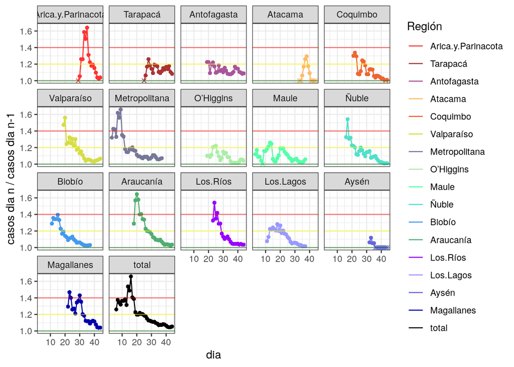

En la serie de tasas de casos nuevos, vemos que hay un reporte en Valparaíso, Metropolitana y Araucanía. Biobío permanece estable, aunque esperamos un aumento cuando se consideren los casos del brote del Sanatorio Alemán.

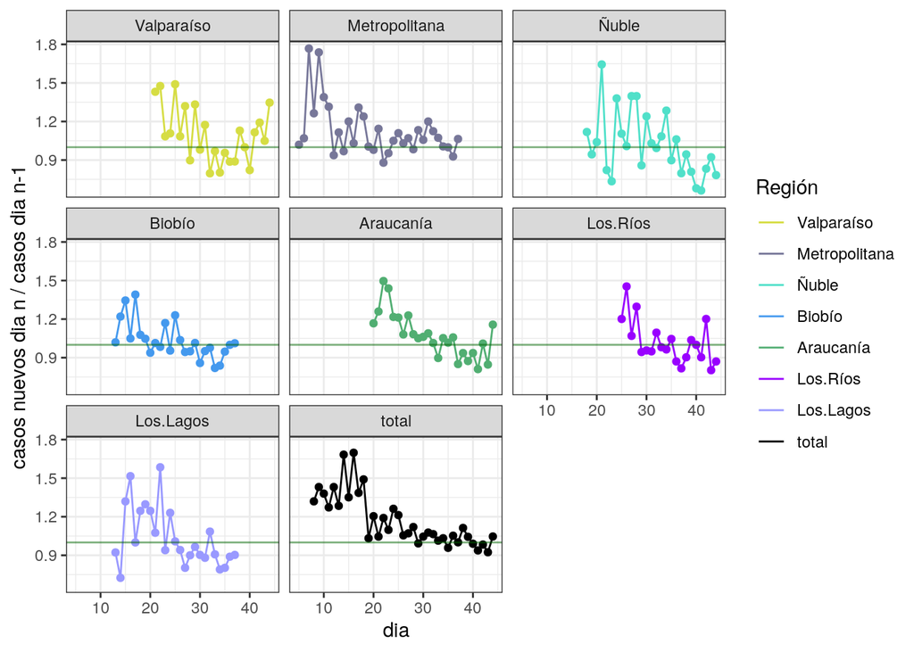

## Predicción

### Predicción para serie total

Recordemos que la regresión exponencial se eliminó, porque ya no calza con la serie total. El informe de la semana pasada mostró una subestimación constante de los modelos AR(1) + AR(4), y sobreestimación (lo que sabíamos), del modelo ARIMA. . Este último modelo se eliminará, ya que si bien los intervalos de confianza se cumplen, siempre sobreestima. A partir del análisis del resultado del algoritmo de la última semana, para la predicción total se recorta la serie a partir de lo 50 casos.

Si observamos la predicción a un 1 día plazo, podemos ver que, el modelo cuadrático (que aparece por primera vez) al igual que T+AR(1)+ T+AR(2) subestiman, pero el cuadrático lo hace un poco menos.

|  | casos | li | ls |
| --- | --- | --- | --- |
| **1** | 8807 | NA | NA |
| **cuad** | 8700 | 8575 | 8825 |
| **tar2** | 8547 | 8428 | 8760 |
| **tar4** | 8622 | 8486 | 8844 |

Podemos ver que modelo cuadrático tiende a ser más pesimista que el T+AR(1) y T+AR(2).

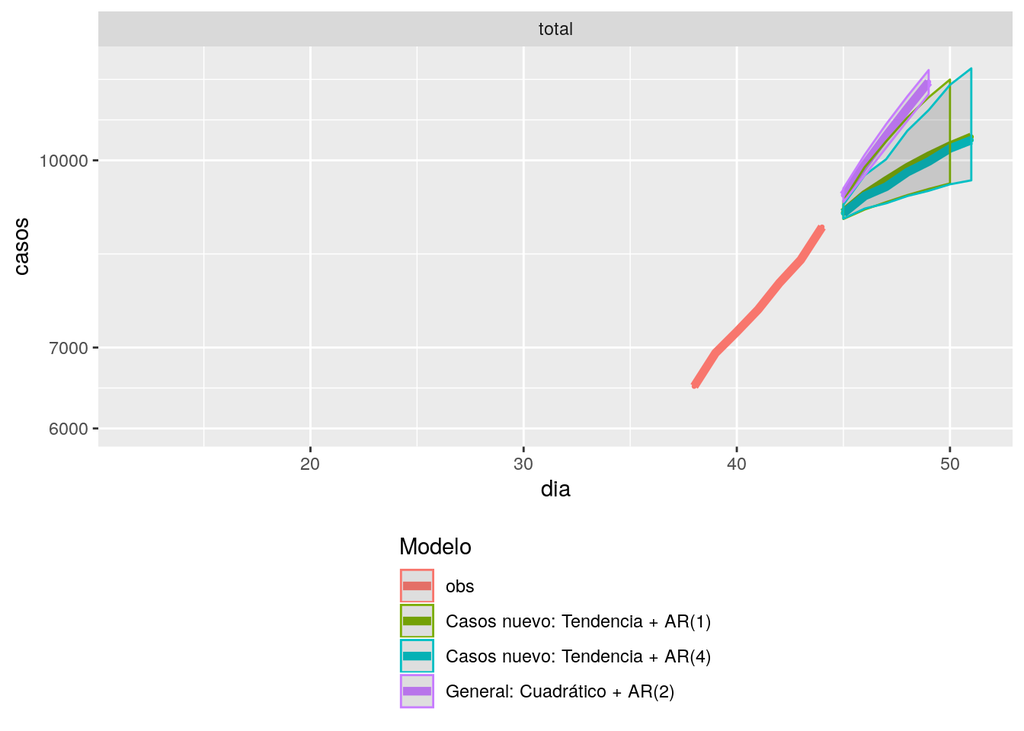

El modelo más pesimistas es el cuadrático, seguido por T+AR(1) y T+AR(4)

Casos nuevos: tendencia + AR(4) : total

|  | dia | casos | li | ls |
| --- | --- | --- | --- | --- |
| **34** | 45 | 9041 | 8949 | 9192 |
| **35** | 46 | 9343 | 9121 | 9721 |
| **36** | 47 | 9508 | 9213 | 10018 |
| **37** | 48 | 9777 | 9342 | 10579 |
| **38** | 49 | 9977 | 9436 | 11004 |
| **39** | 50 | 10229 | 9554 | 11546 |
| **40** | 51 | 10393 | 9626 | 11916 |

Casos nuevos: tendencia + AR(1) : total

|  | dia | casos | li | ls |
| --- | --- | --- | --- | --- |
| **34** | 45 | 9054 | 8942 | 9258 |
| **35** | 46 | 9370 | 9105 | 9871 |
| **36** | 47 | 9622 | 9234 | 10366 |
| **37** | 48 | 9868 | 9359 | 10850 |
| **38** | 49 | 10085 | 9469 | 11276 |
| **39** | 50 | 10282 | 9569 | 11664 |
| **40** | 51 | 10457 | 9658 | 12008 |

General: Modelo cuadrático : total

|  | dia | casos | li | ls |
| --- | --- | --- | --- | --- |
| **34** | 45 | 9358 | 9236 | 9479 |
| **35** | 46 | 9914 | 9722 | 10107 |
| **36** | 47 | 10475 | 10240 | 10709 |
| **37** | 48 | 11039 | 10782 | 11296 |
| **38** | 49 | 11609 | 11342 | 11877 |
| **39** | 50 | 12188 | 11916 | 12459 |
| **40** | 51 | 12776 | 12503 | 13049 |

### Predicciones para serie total usando predicción por regiones.

Otro modelo posible de análisis es usar la suma de las predicciones parciales por región. No he calculado los intervalos de confianza, porque para que sean adecuados debería considerar la covarianza entre las series de las distintas regiones.

El modelo cuadrático también entrega una predicción más pesimista si se suman las series, al igual que en el caso de la serie total.

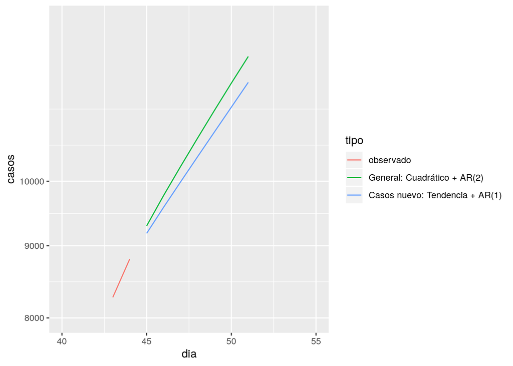

| dia | tipo | casos |
| --- | --- | --- |
| 1 | observado | 1 |
| 2 | observado | 3 |
| 3 | observado | 4 |
| 4 | observado | 5 |
| 5 | observado | 7 |
| 6 | observado | 10 |
| 7 | observado | 13 |
| 8 | observado | 17 |
| 9 | observado | 23 |
| 10 | observado | 33 |
| 11 | observado | 43 |
| 12 | observado | 61 |
| 13 | observado | 75 |
| 14 | observado | 156 |
| 15 | observado | 201 |
| 16 | observado | 342 |
| 17 | observado | 434 |
| 18 | observado | 537 |
| 19 | observado | 632 |
| 20 | observado | 746 |
| 21 | observado | 922 |
| 22 | observado | 1142 |
| 23 | observado | 1306 |
| 24 | observado | 1610 |
| 25 | observado | 1909 |
| 26 | observado | 2139 |
| 27 | observado | 2449 |
| 28 | observado | 2738 |
| 29 | observado | 3031 |
| 30 | observado | 3404 |
| 31 | observado | 3737 |
| 32 | observado | 4161 |
| 33 | observado | 4471 |
| 34 | observado | 4815 |
| 35 | observado | 5116 |
| 36 | observado | 5546 |
| 37 | observado | 5972 |
| 38 | observado | 6501 |
| 39 | observado | 6927 |
| 40 | observado | 7213 |
| 41 | observado | 7525 |
| 42 | observado | 7917 |
| 43 | observado | 8273 |
| 44 | observado | 8807 |
| 45 | General: Cuadrático + AR(2) | 9297 |
| 46 | General: Cuadrático + AR(2) | 9769 |
| 47 | General: Cuadrático + AR(2) | 10242 |
| 48 | General: Cuadrático + AR(2) | 10725 |
| 49 | General: Cuadrático + AR(2) | 11224 |
| 50 | General: Cuadrático + AR(2) | 11735 |
| 51 | General: Cuadrático + AR(2) | 12258 |
| 45 | Casos nuevo: Tendencia + AR(1) | 9184 |
| 46 | Casos nuevo: Tendencia + AR(1) | 9583 |
| 47 | Casos nuevo: Tendencia + AR(1) | 9987 |
| 48 | Casos nuevo: Tendencia + AR(1) | 10405 |
| 49 | Casos nuevo: Tendencia + AR(1) | 10836 |
| 50 | Casos nuevo: Tendencia + AR(1) | 11284 |
| 51 | Casos nuevo: Tendencia + AR(1) | 11751 |

### Predicción por regiones

Eliminaremos la predicción de Atacama y Aysén, que presentan tasas estabilizadas Recordemos que el algoritmo inicia desde 10 casos en cada Región.

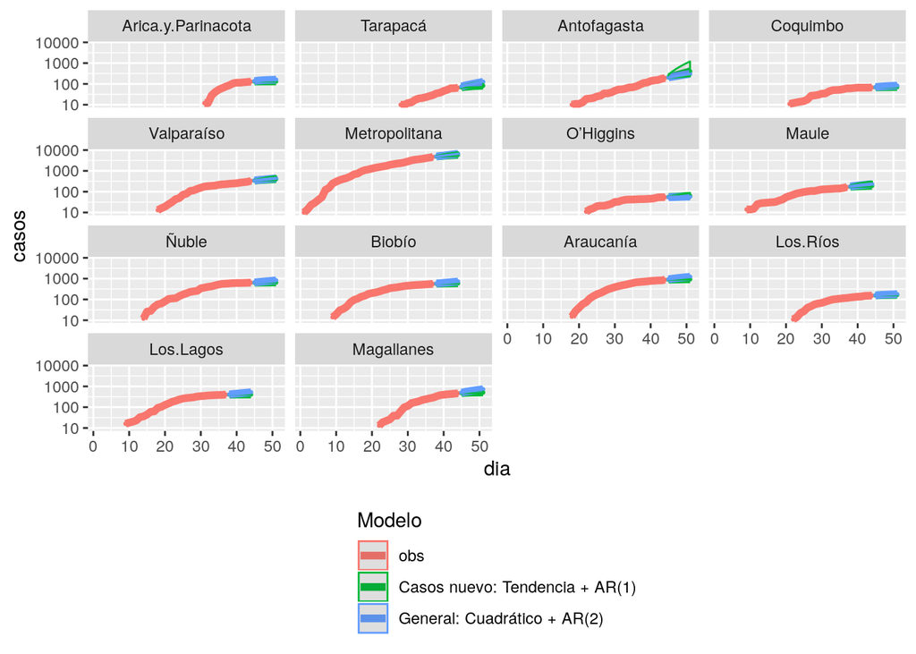

Las tablas por regiones se incluye en el Anexo I

## Decesos

Si observamos la serie de decesos, vemos que se está revirtiendo la desaceleración que habíamos visto en la Metropolitana. También se ve que se estabiliza la serie de la Araucanía.

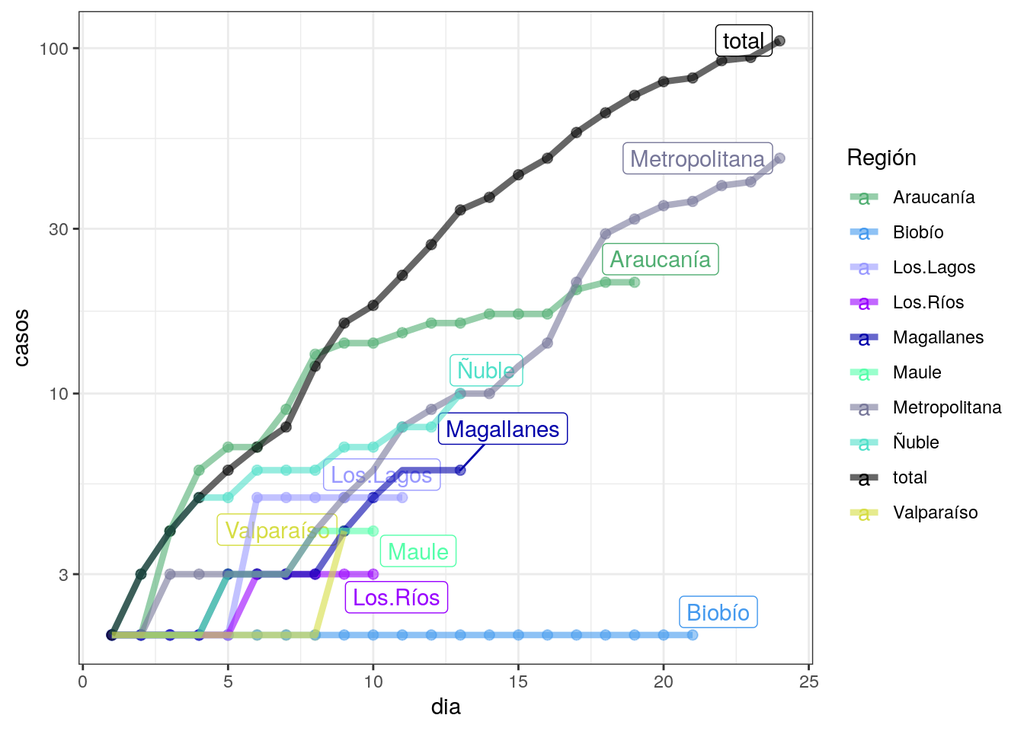

**Fuentes de información**: Principalmente, se utilizó el reporte diario del [MINSAL](https://www.minsal.cl/nuevo-coronavirus-2019-ncov/casos-confirmados-en-chile-covid-19/), usando [Wayback machine](https://archive.org/web/) para recopilar la información ya no disponible.

## Anexo I: Predicciones por región

Casos nuevos: tendencia + AR(1) : Arica.y.Parinacota

|  | dia | casos | li | ls |
| --- | --- | --- | --- | --- |
| **15** | 45 | 130.2 | 129.2 | 137.1 |
| **16** | 46 | 131 | 129.3 | 142 |
| **17** | 47 | 131.4 | 129.4 | 144.6 |
| **18** | 48 | 131.6 | 129.4 | 145.8 |
| **19** | 49 | 131.7 | 129.4 | 146.3 |
| **20** | 50 | 131.7 | 129.4 | 146.6 |
| **21** | 51 | 131.7 | 129.4 | 146.7 |

Casos nuevos: tendencia + AR(1) : Tarapacá

|  | dia | casos | li | ls |
| --- | --- | --- | --- | --- |
| **18** | 45 | 69.29 | 66.89 | 78.24 |
| **19** | 46 | 72.35 | 67.68 | 89.96 |
| **20** | 47 | 75.04 | 68.38 | 100.3 |
| **21** | 48 | 77.37 | 68.99 | 109.3 |
| **22** | 49 | 79.36 | 69.51 | 116.9 |
| **23** | 50 | 81.02 | 69.94 | 123.3 |
| **24** | 51 | 82.37 | 70.29 | 128.5 |

Casos nuevos: tendencia + AR(1) : Antofagasta

|  | dia | casos | li | ls |
| --- | --- | --- | --- | --- |
| **28** | 45 | 211.7 | 196.2 | 284.2 |
| **29** | 46 | 233.7 | 200.7 | 391.4 |
| **30** | 47 | 258.8 | 205.9 | 514.4 |
| **31** | 48 | 287.5 | 211.7 | 654.5 |
| **32** | 49 | 320.3 | 218.4 | 814.8 |
| **33** | 50 | 357.8 | 226.1 | 998.3 |
| **34** | 51 | 400.9 | 234.9 | 1209 |

Casos nuevos: tendencia + AR(1) : Coquimbo

|  | dia | casos | li | ls |
| --- | --- | --- | --- | --- |
| **25** | 45 | 68.69 | 68.16 | 71 |
| **26** | 46 | 69.32 | 68.3 | 73.83 |
| **27** | 47 | 69.81 | 68.41 | 76.02 |
| **28** | 48 | 70.2 | 68.5 | 77.72 |
| **29** | 49 | 70.49 | 68.56 | 79.02 |
| **30** | 50 | 70.7 | 68.61 | 79.99 |
| **31** | 51 | 70.86 | 68.65 | 80.7 |

Casos nuevos: tendencia + AR(1) : Valparaíso

|  | dia | casos | li | ls |
| --- | --- | --- | --- | --- |
| **28** | 45 | 342.4 | 333.7 | 371.5 |
| **29** | 46 | 353.2 | 336.9 | 408.1 |
| **30** | 47 | 363.4 | 339.9 | 442.6 |
| **31** | 48 | 373.1 | 342.8 | 475.3 |
| **32** | 49 | 382.2 | 345.4 | 506.1 |
| **33** | 50 | 390.7 | 348 | 534.9 |
| **34** | 51 | 398.6 | 350.3 | 561.8 |

Casos nuevos: tendencia + AR(1) : Metropolitana

|  | dia | casos | li | ls |
| --- | --- | --- | --- | --- |
| **38** | 38 | 4912 | 4775 | 5254 |
| **39** | 39 | 5113 | 4853 | 5764 |
| **40** | 40 | 5298 | 4926 | 6237 |
| **41** | 41 | 5470 | 4993 | 6679 |
| **42** | 42 | 5631 | 5056 | 7090 |
| **43** | 43 | 5780 | 5114 | 7470 |
| **44** | 44 | 5917 | 5168 | 7819 |

Casos nuevos: tendencia + AR(1) : O’Higgins

|  | dia | casos | li | ls |
| --- | --- | --- | --- | --- |
| **24** | 45 | 55.27 | 54.34 | 58.71 |
| **25** | 46 | 56.56 | 54.69 | 63.51 |
| **26** | 47 | 57.85 | 55.04 | 68.3 |
| **27** | 48 | 59.14 | 55.38 | 73.09 |
| **28** | 49 | 60.43 | 55.73 | 77.89 |
| **29** | 50 | 61.73 | 56.08 | 82.71 |
| **30** | 51 | 63.03 | 56.43 | 87.56 |

Casos nuevos: tendencia + AR(1) : Maule

|  | dia | casos | li | ls |
| --- | --- | --- | --- | --- |
| **30** | 38 | 172.7 | 168 | 199.1 |
| **31** | 39 | 176.9 | 168.7 | 223.9 |
| **32** | 40 | 180.5 | 169.3 | 245.4 |
| **33** | 41 | 183.7 | 169.9 | 264.7 |
| **34** | 42 | 186.6 | 170.3 | 282 |
| **35** | 43 | 189.2 | 170.8 | 297.4 |
| **36** | 44 | 191.5 | 171.2 | 311.1 |

Casos nuevos: tendencia + AR(1) : Ñuble

|  | dia | casos | li | ls |
| --- | --- | --- | --- | --- |
| **32** | 45 | 643 | 640 | 655.9 |
| **33** | 46 | 646.1 | 640.7 | 669 |
| **34** | 47 | 648.5 | 641.2 | 678.9 |
| **35** | 48 | 650.2 | 641.7 | 686.3 |
| **36** | 49 | 651.5 | 642 | 691.7 |
| **37** | 50 | 652.4 | 642.2 | 695.6 |
| **38** | 51 | 653.1 | 642.3 | 698.4 |

Casos nuevos: tendencia + AR(1) : Biobío

|  | dia | casos | li | ls |
| --- | --- | --- | --- | --- |
| **30** | 38 | 568 | 563.2 | 578.2 |
| **31** | 39 | 575.6 | 566.8 | 594.4 |
| **32** | 40 | 582 | 569.7 | 608.1 |
| **33** | 41 | 587.3 | 572.2 | 619.5 |
| **34** | 42 | 591.6 | 574.2 | 628.8 |
| **35** | 43 | 595.1 | 575.9 | 636.3 |
| **36** | 44 | 598 | 577.2 | 642.4 |

Casos nuevos: tendencia + AR(1) : Araucanía

|  | dia | casos | li | ls |
| --- | --- | --- | --- | --- |
| **28** | 45 | 889.5 | 885.6 | 897.8 |
| **29** | 46 | 902.8 | 891.5 | 927.4 |
| **30** | 47 | 910.6 | 895 | 945 |
| **31** | 48 | 917.7 | 898.1 | 961.1 |
| **32** | 49 | 923 | 900.5 | 973 |
| **33** | 50 | 927.2 | 902.3 | 982.5 |
| **34** | 51 | 930.4 | 903.7 | 989.7 |

Casos nuevos: tendencia + AR(1) : Los.Ríos

|  | dia | casos | li | ls |
| --- | --- | --- | --- | --- |
| **24** | 45 | 155.5 | 154.1 | 158.9 |
| **25** | 46 | 157.7 | 155 | 164.3 |
| **26** | 47 | 159.6 | 155.8 | 168.9 |
| **27** | 48 | 161.2 | 156.4 | 172.8 |
| **28** | 49 | 162.5 | 157 | 176 |
| **29** | 50 | 163.6 | 157.4 | 178.7 |
| **30** | 51 | 164.5 | 157.8 | 180.9 |

Casos nuevos: tendencia + AR(1) : Los.Lagos

|  | dia | casos | li | ls |
| --- | --- | --- | --- | --- |
| **30** | 38 | 401.1 | 399.8 | 404.2 |
| **31** | 39 | 403.6 | 400.7 | 411 |
| **32** | 40 | 405 | 401.3 | 415 |
| **33** | 41 | 406.1 | 401.7 | 418 |
| **34** | 42 | 406.9 | 401.9 | 420.1 |
| **35** | 43 | 407.4 | 402.1 | 421.4 |
| **36** | 44 | 407.7 | 402.2 | 422.3 |

Casos nuevos: tendencia + AR(1) : Magallanes

|  | dia | casos | li | ls |
| --- | --- | --- | --- | --- |
| **24** | 45 | 477.1 | 469.6 | 505.8 |
| **25** | 46 | 486.9 | 472 | 546.5 |
| **26** | 47 | 494.2 | 473.8 | 576.4 |
| **27** | 48 | 499.8 | 475.1 | 599.7 |
| **28** | 49 | 503.9 | 476.1 | 616.9 |
| **29** | 50 | 506.9 | 476.8 | 629.4 |
| **30** | 51 | 509.1 | 477.4 | 638.2 |

General: cuadrático + AR(2) : Arica.y.Parinacota

|  | dia | casos | li | ls |
| --- | --- | --- | --- | --- |
| **15** | 45 | 137.4 | 126.7 | 148.1 |
| **16** | 46 | 144.9 | 131.7 | 158.1 |
| **17** | 47 | 150 | 136.7 | 163.3 |
| **18** | 48 | 153.4 | 139.9 | 166.8 |
| **19** | 49 | 156 | 142.3 | 169.6 |
| **20** | 50 | 158.4 | 144.7 | 172.1 |
| **21** | 51 | 160.6 | 146.9 | 174.2 |

General: cuadrático + AR(2) : Tarapacá

|  | dia | casos | li | ls |
| --- | --- | --- | --- | --- |
| **18** | 45 | 75.65 | 71.46 | 79.83 |
| **19** | 46 | 84.69 | 80.32 | 89.07 |
| **20** | 47 | 92.23 | 87.76 | 96.7 |
| **21** | 48 | 99.88 | 95.36 | 104.4 |
| **22** | 49 | 108.4 | 103.9 | 112.9 |
| **23** | 50 | 117.6 | 113 | 122.1 |
| **24** | 51 | 127 | 122.5 | 131.6 |

General: cuadrático + AR(2) : Antofagasta

|  | dia | casos | li | ls |
| --- | --- | --- | --- | --- |
| **28** | 45 | 205.7 | 197.2 | 214.1 |
| **29** | 46 | 220.4 | 210.2 | 230.5 |
| **30** | 47 | 236 | 225.2 | 246.8 |
| **31** | 48 | 252.5 | 241.4 | 263.6 |
| **32** | 49 | 269.7 | 258.5 | 280.9 |
| **33** | 50 | 287.6 | 276.4 | 298.9 |
| **34** | 51 | 306.2 | 295 | 317.5 |

General: cuadrático + AR(2) : Coquimbo

|  | dia | casos | li | ls |
| --- | --- | --- | --- | --- |
| **25** | 45 | 70.99 | 65.92 | 76.06 |
| **26** | 46 | 73.78 | 66.98 | 80.59 |
| **27** | 47 | 76.13 | 68.76 | 83.5 |
| **28** | 48 | 78.11 | 70.6 | 85.61 |
| **29** | 49 | 79.82 | 72.3 | 87.35 |
| **30** | 50 | 81.38 | 73.85 | 88.91 |
| **31** | 51 | 82.83 | 75.3 | 90.36 |

General: cuadrático + AR(2) : Valparaíso

|  | dia | casos | li | ls |
| --- | --- | --- | --- | --- |
| **28** | 45 | 346.8 | 332 | 361.6 |
| **29** | 46 | 361.6 | 341.5 | 381.8 |
| **30** | 47 | 376.4 | 353.6 | 399.3 |
| **31** | 48 | 391.5 | 367.2 | 415.8 |
| **32** | 49 | 406.9 | 381.9 | 432 |
| **33** | 50 | 422.6 | 397.1 | 448.1 |
| **34** | 51 | 438.6 | 412.8 | 464.3 |

General: cuadrático + AR(2) : Metropolitana

|  | dia | casos | li | ls |
| --- | --- | --- | --- | --- |
| **38** | 38 | 4954 | 4866 | 5042 |
| **39** | 39 | 5202 | 5076 | 5328 |
| **40** | 40 | 5456 | 5316 | 5595 |
| **41** | 41 | 5726 | 5584 | 5869 |
| **42** | 42 | 6014 | 5871 | 6157 |
| **43** | 43 | 6317 | 6174 | 6459 |
| **44** | 44 | 6630 | 6487 | 6773 |

General: cuadrático + AR(2) : O’Higgins

|  | dia | casos | li | ls |
| --- | --- | --- | --- | --- |
| **24** | 45 | 54.23 | 51.13 | 57.33 |
| **25** | 46 | 54.79 | 50.73 | 58.85 |
| **26** | 47 | 55.52 | 51.28 | 59.76 |
| **27** | 48 | 56.23 | 51.99 | 60.48 |
| **28** | 49 | 56.85 | 52.6 | 61.1 |
| **29** | 50 | 57.34 | 53.08 | 61.59 |
| **30** | 51 | 57.71 | 53.45 | 61.97 |

General: cuadrático + AR(2) : Maule

|  | dia | casos | li | ls |
| --- | --- | --- | --- | --- |
| **30** | 38 | 179.4 | 172.3 | 186.6 |
| **31** | 39 | 189.7 | 178.3 | 201.1 |
| **32** | 40 | 198.5 | 184.9 | 212.2 |
| **33** | 41 | 206.6 | 192 | 221.2 |
| **34** | 42 | 214.6 | 199.7 | 229.4 |
| **35** | 43 | 222.7 | 207.8 | 237.6 |
| **36** | 44 | 231.2 | 216.3 | 246.1 |

General: cuadrático + AR(2) : Ñuble

|  | dia | casos | li | ls |
| --- | --- | --- | --- | --- |
| **32** | 45 | 658.6 | 625.9 | 691.3 |
| **33** | 46 | 684 | 631.6 | 736.4 |
| **34** | 47 | 711.4 | 645.7 | 777 |
| **35** | 48 | 739.3 | 664.9 | 813.6 |
| **36** | 49 | 767.1 | 687.1 | 847.1 |
| **37** | 50 | 794.6 | 710.9 | 878.2 |
| **38** | 51 | 821.7 | 735.7 | 907.8 |

General: cuadrático + AR(2) : Biobío

|  | dia | casos | li | ls |
| --- | --- | --- | --- | --- |
| **30** | 38 | 580.7 | 563.1 | 598.2 |
| **31** | 39 | 604.2 | 576 | 632.3 |
| **32** | 40 | 628.3 | 593.1 | 663.4 |
| **33** | 41 | 652.4 | 612.9 | 691.9 |
| **34** | 42 | 676.4 | 634.1 | 718.6 |
| **35** | 43 | 700.2 | 656.3 | 744 |
| **36** | 44 | 723.8 | 678.9 | 768.6 |

General: cuadrático + AR(2) : Araucanía

|  | dia | casos | li | ls |
| --- | --- | --- | --- | --- |
| **28** | 45 | 937.9 | 911.9 | 963.8 |
| **29** | 46 | 991.6 | 947.6 | 1036 |
| **30** | 47 | 1043 | 986.3 | 1099 |
| **31** | 48 | 1091 | 1028 | 1154 |
| **32** | 49 | 1137 | 1070 | 1204 |
| **33** | 50 | 1182 | 1114 | 1250 |
| **34** | 51 | 1226 | 1158 | 1295 |

General: cuadrático + AR(2) : Los.Ríos

|  | dia | casos | li | ls |
| --- | --- | --- | --- | --- |
| **24** | 45 | 157.8 | 152.5 | 163.1 |
| **25** | 46 | 162.3 | 156.4 | 168.2 |
| **26** | 47 | 166.1 | 160.2 | 172 |
| **27** | 48 | 169.6 | 163.6 | 175.5 |
| **28** | 49 | 172.8 | 166.8 | 178.7 |
| **29** | 50 | 175.7 | 169.8 | 181.7 |
| **30** | 51 | 178.5 | 172.6 | 184.4 |

General: cuadrático + AR(2) : Los.Lagos

|  | dia | casos | li | ls |
| --- | --- | --- | --- | --- |
| **30** | 38 | 412.7 | 396.1 | 429.3 |
| **31** | 39 | 429 | 400.5 | 457.5 |
| **32** | 40 | 446.5 | 409 | 484.1 |
| **33** | 41 | 464.6 | 420.7 | 508.6 |
| **34** | 42 | 483 | 434.6 | 531.4 |
| **35** | 43 | 501.3 | 449.9 | 552.6 |
| **36** | 44 | 519.5 | 466.2 | 572.8 |

General: cuadrático + AR(2) : Magallanes

|  | dia | casos | li | ls |
| --- | --- | --- | --- | --- |
| **24** | 45 | 502.5 | 479.8 | 525.3 |
| **25** | 46 | 541.8 | 509.1 | 574.5 |
| **26** | 47 | 580.8 | 544.4 | 617.1 |
| **27** | 48 | 618.3 | 581 | 655.5 |
| **28** | 49 | 654.7 | 617.3 | 692 |
| **29** | 50 | 690.8 | 653.4 | 728.1 |
| **30** | 51 | 727.1 | 689.8 | 764.5 |